# Height-for-age Z-score in Peruvian children aged 6-59 months

Dataset 5: Peru DHS child anaemia and growth extract

RSR feasibility analysis

2026-08-03

# Introduction

Chronic undernutrition, measured as height-for-age relative to the WHO growth standard, remains a major child-health problem in Peru despite two decades of economic growth and targeted nutrition programmes. The Peruvian Demographic and Health Survey (ENDES) anthropometry module measures every surveyed child aged 6-59 months, giving a large cross-sectional picture of how linear growth varies with birth history, maternal circumstances, household wealth and geography. Height-for-age Z-score (HAZ) is the continuous form of the indicator that is usually dichotomised into “stunting”; analysing it continuously uses the whole distribution rather than only the tail below -2.

**Aim.** Among Peruvian children aged 6-59 months, we examined which of child age, child sex, birth-weight category, maternal education, household wealth, natural region and maternal indigenous identity are independently associated with height-for-age Z-score, mutually adjusting for the others.

This is a *Purpose 3* analysis: several predictors are of interest and the question is which remain associated with the outcome after mutual adjustment.

# Methods

**Data source.** A cross-sectional extract of 19191 children aged 6-59 months from the Peru Demographic and Health Survey (ENDES), a nationally implemented household survey. Each row is one child with measured length or height, linked to the mother’s interview and household characteristics.

**Variables.** The outcome is `height_for_age_z`, the WHO height-for-age Z-score (dimensionless; 0 is the reference-population median, and one unit is one reference standard deviation). Predictors are child age in months (continuous, 6-59); child sex (reference *Female*); maternally reported birth-weight category (reference *Normal*, versus *Low* i.e. below 2.5 kg and *Macrosomia*); mother’s highest education (reference *Primary or none*); household wealth quintile (reference *Poorest*); natural region (reference *Lima metropolitan*); and maternal indigenous identity (reference *No*). These seven span birth endowment, maternal human capital, household resources and geography, the four channels through which linear growth is conventionally modelled.

`stunting` is excluded as a predictor because it is a deterministic function of this outcome (`stunting = height_for_age_z < -2`); haemoglobin and anaemia are also excluded because they are co-outcomes of undernutrition rather than exposures.

**Statistical analysis.** Linear regression via `lm()`, justified because the outcome is continuous and approximately normally distributed. We fitted a univariable model for each predictor first, then a single multivariable model containing all of them. Predictors were chosen in advance on subject-matter grounds, not by significance. Significance threshold 0.05; estimates are reported with 95% confidence intervals. Assumptions were checked with `performance::check_model()`. Analysis used R version 4.6.0 (2026-04-24) with tidyverse, gtsummary and performance.

**Missing data.** Complete-case analysis: 18640 of 19191 rows were analysed (551 dropped, 2.9%). Essentially all of the loss comes from missing maternally reported birth weight, which is missing for children whose mothers could not recall or did not report a size at birth.

# Results

## Sample characteristics

**Table 1. Sample characteristics.**

| **Characteristic** | **N** | **N = 18,640**<sup>1</sup> |
| --- | --- | --- |
| Height-for-age Z-score | 18,640 | -0.79 (-1.47, -0.12) |
| Child age (months) | 18,640 | 33 (19, 46) |
| Child sex | 18,640 |  |
| Female |  | 8,997 (48%) |
| Male |  | 9,643 (52%) |
| Birth-weight category (maternal report) | 18,640 |  |
| Normal |  | 15,997 (86%) |
| Low (<2.5 kg) |  | 1,165 (6.3%) |
| Macrosomia |  | 1,478 (7.9%) |
| Mother's education | 18,640 |  |
| Primary or none |  | 3,318 (18%) |
| Secondary |  | 9,312 (50%) |
| Higher |  | 6,010 (32%) |
| Household wealth quintile | 18,640 |  |
| Poorest |  | 5,570 (30%) |
| Poorer |  | 5,094 (27%) |
| Middle |  | 3,751 (20%) |
| Richer |  | 2,579 (14%) |
| Richest |  | 1,646 (8.8%) |
| Natural region | 18,640 |  |
| Lima metropolitan |  | 2,298 (12%) |
| Rest of coast |  | 5,446 (29%) |
| Highlands |  | 6,217 (33%) |
| Jungle |  | 4,679 (25%) |
| Mother indigenous | 18,640 | 1,794 (9.6%) |

<sup>1</sup> Median (Q1, Q3); n (%)

Median HAZ was -0.79 (IQR -1.47 to -0.12): the whole distribution is shifted roughly three quarters of a standard deviation below the WHO reference median, and 12.2% of children fall below the -2 stunting threshold. 6.2% of children were reported as low birth weight, close to the figure usually cited for Peru.

## Exploratory figure

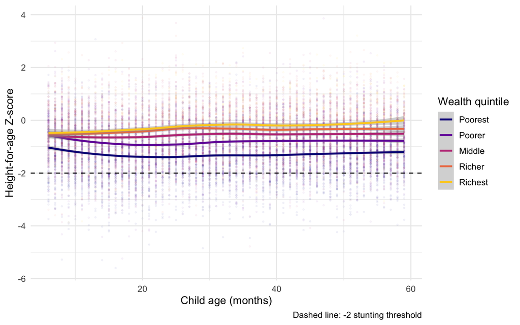

Figure 1. Height-for-age Z-score against child age, by household wealth quintile, with LOESS smoothers.

## Univariable models

| **Characteristic** | **N** | **Beta** | **95% CI** | **p-value** |
| --- | --- | --- | --- | --- |
| Child age (months) | 18,640 | 0.00 | 0.00, 0.00 | <0.001 |
| Child sex | 18,640 |  |  |  |
| Female |  | — | — |  |
| Male |  | -0.03 | -0.06, 0.00 | 0.067 |
| Birth-weight category (maternal report) | 18,640 |  |  |  |
| Normal |  | — | — |  |
| Low (<2.5 kg) |  | -0.59 | -0.65, -0.53 | <0.001 |
| Macrosomia |  | 0.57 | 0.51, 0.62 | <0.001 |
| Mother's education | 18,640 |  |  |  |
| Primary or none |  | — | — |  |
| Secondary |  | 0.45 | 0.41, 0.49 | <0.001 |
| Higher |  | 0.81 | 0.77, 0.86 | <0.001 |
| Household wealth quintile | 18,640 |  |  |  |
| Poorest |  | — | — |  |
| Poorer |  | 0.47 | 0.44, 0.51 | <0.001 |
| Middle |  | 0.72 | 0.68, 0.76 | <0.001 |
| Richer |  | 0.90 | 0.86, 0.95 | <0.001 |
| Richest |  | 1.0 | 1.0, 1.1 | <0.001 |
| Natural region | 18,640 |  |  |  |
| Lima metropolitan |  | — | — |  |
| Rest of coast |  | -0.09 | -0.14, -0.04 | <0.001 |
| Highlands |  | -0.74 | -0.79, -0.69 | <0.001 |
| Jungle |  | -0.51 | -0.56, -0.46 | <0.001 |
| Mother indigenous | 18,640 |  |  |  |
| No |  | — | — |  |
| Yes |  | -0.70 | -0.75, -0.65 | <0.001 |

Abbreviation: CI = Confidence Interval

Low birth weight is the strongest single child-level predictor: children reported as weighing under 2.5 kg at birth average -0.59 Z-scores lower than normal-birth-weight children (95% CI -0.65 to -0.53, p < 0.001), a deficit of more than half a reference standard deviation that persists years after birth. The socio-economic gradients are larger still – richest versus poorest quintile is 1.05 Z-scores – and child sex is the only predictor that is *not* significant even crudely (-0.027, p = 0.067), which is worth noting in a dataset this large.

## Why adjustment is needed

The crude estimates confuse several strongly overlapping gradients. **Household wealth** confounds the maternal-indigenous contrast: indigenous mothers in this extract are heavily concentrated in the poorest quintiles, and poverty independently limits dietary quality, sanitation and health-service access, so a crude indigenous-versus-not comparison is largely a poor-versus-rich comparison. **Maternal education** confounds the wealth gradient in turn: better-educated mothers live in wealthier households *and* independently practise better infant feeding and seek care earlier, so part of the raw wealth effect belongs to schooling. **Natural region** confounds both: the highlands and jungle are simultaneously poorer, more indigenous and less schooled than Lima, and also differ in altitude, food systems and service coverage. Finally **birth weight** is itself socially patterned, so the crude birth-weight coefficient partly reflects the circumstances that produced the low birth weight rather than the birth weight itself. Mutual adjustment is required before any of these can be read as an independent association.

## Multivariable model

| **Characteristic** | **Beta** | **95% CI** | **p-value** |
| --- | --- | --- | --- |
| Child age (months) | 0.00 | 0.00, 0.00 | <0.001 |
| Child sex |  |  |  |
| Female | — | — |  |
| Male | -0.02 | -0.05, 0.00 | 0.094 |
| Birth-weight category (maternal report) |  |  |  |
| Normal | — | — |  |
| Low (<2.5 kg) | -0.52 | -0.57, -0.46 | <0.001 |
| Macrosomia | 0.45 | 0.40, 0.50 | <0.001 |
| Mother's education |  |  |  |
| Primary or none | — | — |  |
| Secondary | 0.24 | 0.20, 0.27 | <0.001 |
| Higher | 0.39 | 0.35, 0.44 | <0.001 |
| Household wealth quintile |  |  |  |
| Poorest | — | — |  |
| Poorer | 0.24 | 0.20, 0.28 | <0.001 |
| Middle | 0.39 | 0.35, 0.44 | <0.001 |
| Richer | 0.50 | 0.45, 0.55 | <0.001 |
| Richest | 0.59 | 0.53, 0.66 | <0.001 |
| Natural region |  |  |  |
| Lima metropolitan | — | — |  |
| Rest of coast | 0.01 | -0.04, 0.05 | 0.7 |
| Highlands | -0.35 | -0.40, -0.31 | <0.001 |
| Jungle | -0.16 | -0.21, -0.11 | <0.001 |
| Mother indigenous |  |  |  |
| No | — | — |  |
| Yes | -0.15 | -0.20, -0.10 | <0.001 |

Abbreviation: CI = Confidence Interval

Model fit

| Statistic | Value |
| --- | --- |
| R-squared | 0.198 |
| Adjusted R-squared | 0.198 |
| Residual SD (Z-scores) | 0.916 |
| Observations | 18640.000 |
| Model parameters | 15.000 |

The model explains 19.8% of the variance in HAZ (adjusted R-squared 0.198), which is respectable for individual-level anthropometry but still leaves four fifths of the variation unexplained. Holding the other six predictors constant, low birth weight is associated with a -0.52 Z-score deficit (95% CI -0.57 to -0.46) and macrosomia with a 0.45 Z-score advantage (95% CI 0.4 to 0.5), a spread of about one Z-score across the birth-weight categories. The wealth gradient remains monotonic and substantial, 0.59 Z-scores from poorest to richest (95% CI 0.53 to 0.66). Children in the highlands remain -0.35 Z-scores below Lima children of the same wealth, education, ethnicity and birth weight. Child age contributes almost nothing on a linear scale (0.0025 Z-scores per month) and child sex is not significant (p = 0.09).

## Unadjusted versus adjusted

**Table 2. Unadjusted and adjusted estimates.**

| **Characteristic** | **Unadjusted** **N** | **Unadjusted** **Beta** | **Unadjusted** **95% CI** | **Unadjusted** **p-value** | **Adjusted** **Beta** | **Adjusted** **95% CI** | **Adjusted** **p-value** |
| --- | --- | --- | --- | --- | --- | --- | --- |
| Child age (months) | 18,640 | 0.00 | 0.00, 0.00 | <0.001 | 0.00 | 0.00, 0.00 | <0.001 |
| Child sex | 18,640 |  |  |  |  |  |  |
| Female |  | — | — |  | — | — |  |
| Male |  | -0.03 | -0.06, 0.00 | 0.067 | -0.02 | -0.05, 0.00 | 0.094 |
| Birth-weight category (maternal report) | 18,640 |  |  |  |  |  |  |
| Normal |  | — | — |  | — | — |  |
| Low (<2.5 kg) |  | -0.59 | -0.65, -0.53 | <0.001 | -0.52 | -0.57, -0.46 | <0.001 |
| Macrosomia |  | 0.57 | 0.51, 0.62 | <0.001 | 0.45 | 0.40, 0.50 | <0.001 |
| Mother's education | 18,640 |  |  |  |  |  |  |
| Primary or none |  | — | — |  | — | — |  |
| Secondary |  | 0.45 | 0.41, 0.49 | <0.001 | 0.24 | 0.20, 0.27 | <0.001 |
| Higher |  | 0.81 | 0.77, 0.86 | <0.001 | 0.39 | 0.35, 0.44 | <0.001 |
| Household wealth quintile | 18,640 |  |  |  |  |  |  |
| Poorest |  | — | — |  | — | — |  |
| Poorer |  | 0.47 | 0.44, 0.51 | <0.001 | 0.24 | 0.20, 0.28 | <0.001 |
| Middle |  | 0.72 | 0.68, 0.76 | <0.001 | 0.39 | 0.35, 0.44 | <0.001 |
| Richer |  | 0.90 | 0.86, 0.95 | <0.001 | 0.50 | 0.45, 0.55 | <0.001 |
| Richest |  | 1.0 | 1.0, 1.1 | <0.001 | 0.59 | 0.53, 0.66 | <0.001 |
| Natural region | 18,640 |  |  |  |  |  |  |
| Lima metropolitan |  | — | — |  | — | — |  |
| Rest of coast |  | -0.09 | -0.14, -0.04 | <0.001 | 0.01 | -0.04, 0.05 | 0.7 |
| Highlands |  | -0.74 | -0.79, -0.69 | <0.001 | -0.35 | -0.40, -0.31 | <0.001 |
| Jungle |  | -0.51 | -0.56, -0.46 | <0.001 | -0.16 | -0.21, -0.11 | <0.001 |
| Mother indigenous | 18,640 |  |  |  |  |  |  |
| No |  | — | — |  | — | — |  |
| Yes |  | -0.70 | -0.75, -0.65 | <0.001 | -0.15 | -0.20, -0.10 | <0.001 |

Abbreviation: CI = Confidence Interval

## Diagnostics

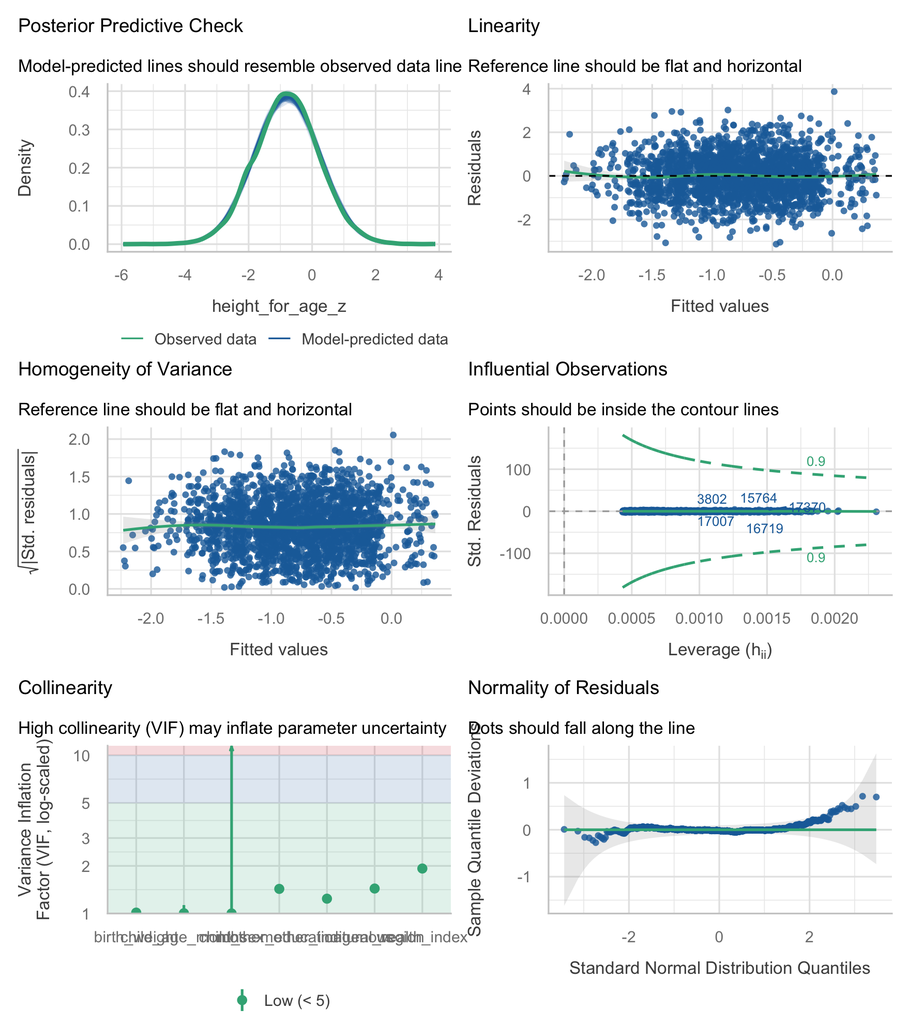

# Discussion

Linear growth in Peruvian preschool children tracks household circumstances more than anything else measured here: moving from the poorest to the richest quintile is associated with about 0.59 Z-scores of height-for-age, and living in the highlands with about 0.35 Z-scores less than Lima, after mutual adjustment. Birth endowment matters too and matters independently: the -0.52 Z-score deficit for low birth weight is barely touched by adjustment, so children who start small stay small regardless of the household they grow up in. Practically, that argues for both antenatal interventions that raise birth weight and continued postnatal nutrition support in highland and poorest-quintile communities.

**Limitations.** This is cross-sectional: HAZ is measured once, birth weight is recalled, and no causal interpretation is warranted. Birth weight is a **maternally reported three-level category**, not a measured weight in kilograms, so it is subject to recall and heaping bias and the “macrosomia” group in particular may capture perception of a large baby rather than a measured >4 kg weight. The source ENDES analysis used the DHS complex design – cluster (HV001), stratum (HV022) and sampling weights – whereas this extract carries only the weight variable, which is deliberately not used; standard errors are therefore too narrow, estimates are not design-corrected, and **this sample must not be described as nationally representative**. With 18640 rows almost every comparison reaches statistical significance, so interpretation must lead with effect sizes rather than p-values. Key confounders are absent entirely: maternal height (the single strongest determinant of child height), birth order and interval, infection history, and dietary diversity. The linear age term is mis-specified. A small number of extreme Z-scores below -5 are probably data errors and were retained rather than trimmed. Finally, the 551 rows dropped for missing birth weight are unlikely to be missing completely at random, since recall of birth size is worse among less-educated mothers, so the complete-case sample is mildly better-off than the full extract.

**Future work.** Refit with the DHS survey design, a spline for age, and maternal height and birth order from the fuller ENDES recode file.

# Feasibility notes

*Not part of a student report.*

- **Works well.** Probably the best of the five outcomes for a student. Large effect sizes that are easy to talk about, a genuinely instructive confounding story (indigenous identity attenuating by 78%), no collinearity problems (max VIF 1.92), and adjusted R-squared 0.198, the highest of the five models.
- **Deterministic-twin trap.** `stunting` is exactly `height_for_age_z < -2`. It must never enter this model. A student who runs “all variables” without thinking will get an R-squared near 0.7 and a nonsense model.
- **Non-linear age.** The age-HAZ relationship is U-shaped (nadir around 18 months), so the linear term is close to useless (0.0025 per month). Fine as a teaching point, but students must be told to plot before modelling.
- **Birth weight is categorical, not kg.** The codebook wording invites students to treat `birth_weight` as continuous. It is a three-level string, and “macrosomia” is *not* an ordered extension of “low”-“normal” in the risk sense for this outcome (both tails are informative, in opposite directions).
- **Implausible values.** A few HAZ values below -5 and above +3.5 survive in the file. They do not break the model but they should be discussed.
- **Missingness.** 551 rows (2.9%) are lost to missing birth weight. Not a threat, but it makes this model’s N differ from the haemoglobin model’s, which confuses students who compare tables across outcomes.
- **Design not honoured.** Only the weight is present, not cluster or stratum, so a design-correct analysis is impossible here.